# project

```r
cat(sprintf("Accuracy = %.4f\n", metrics_point$accuracy))
```

```
## Accuracy = 0.8056
```

```r
cat(sprintf("BER      = %.4f\n", metrics_point$BER))
```

```
## BER      = 0.1944
```

```r
cat(sprintf("Kappa    = %.4f\n", metrics_point$kappa))
```

```
## Kappa    = 0.6111
```

```r
cat(sprintf("Sens(F)  = %.4f | Spec(F) = %.4f\n", metrics_point$sensitivity_female, metrics_point$specificity_female))
```

```
## Sens(F)  = 0.8889 | Spec(F) = 0.7222
```

```r
cat(sprintf("Sens(M)  = %.4f | Spec(M) = %.4f\n", metrics_point$sensitivity_male, metrics_point$specificity_male))
```

```
## Sens(M)  = 0.7222 | Spec(M) = 0.8889
```

```r
cat(sprintf("AUCROC   = %.4f\n", auc_point))
```

```
## AUCROC   = 0.8333
```

```r
# Bootstrap CIs for Accuracy, BER, Kappa, Sens/Spec (both classes), and AUC
set.seed(123)
n_boot <- 1000

boot_acc  <- numeric(n_boot)
boot_ber  <- numeric(n_boot)
boot_kappa<- numeric(n_boot)
boot_sensF<- numeric(n_boot)
boot_specF<- numeric(n_boot)
boot_sensM<- numeric(n_boot)
boot_specM<- numeric(n_boot)
boot_auc  <- numeric(n_boot)

for (i in 1:n_boot) {
  idx <- sample(seq_along(y_test), replace = TRUE)
  Xb <- X_test_optimal[idx, ]
  yb <- y_test[idx]

  pred_b <- predict(pls_final_optimal, Xb)
  class_b <- pred_b$class$max.dist[, optimal_ncomp]
  cm <- table(True = yb, Predicted = class_b)

  # Guard: ensure 2x2 matrix even if a class is missing
  all_lvls <- levels(y_test)
  cm <- as.matrix(cm)
  # Rebuild complete 2x2 in fixed order (Female, Male)
  full_cm <- matrix(0, nrow = 2, ncol = 2,
                    dimnames = list(True = all_lvls, Predicted = all_lvls))
  for (tr in rownames(cm)) for (pr in colnames(cm)) full_cm[tr, pr] <- cm[tr, pr]
  cm <- full_cm

  TP1 <- cm["Female","Female"]; FN1 <- cm["Female","Male"]
  FP1 <- cm["Male","Female"];   TN1 <- cm["Male","Male"]

  acc <- (TP1 + TN1) / sum(cm)
  sensF <- if ((TP1 + FN1) > 0) TP1 / (TP1 + FN1) else NA
  specF <- if ((TN1 + FP1) > 0) TN1 / (TN1 + FP1) else NA
  sensM <- if ((TN1 + FP1) > 0) TN1 / (TN1 + FP1) else NA
  specM <- if ((TP1 + FN1) > 0) TP1 / (TP1 + FN1) else NA
  ber   <- 1 - mean(c(sensF, sensM), na.rm = TRUE)

  po <- acc
  pe <- ((sum(cm["Female",]) * sum(cm[,"Female"])) + (sum(cm["Male",]) * sum(cm[,"Male"]))) / (sum(cm)^2)
  kappa <- if ((1 - pe) > 0) (po - pe) / (1 - pe) else NA

  # AUC from scores (skip if a single class)
  scores_b <- pred_b$predict[,1,optimal_ncomp]
  yb_num <- as.numeric(yb) - 1
  if (length(unique(yb_num)) == 2) {
    boot_auc[i] <- as.numeric(auc(roc(yb_num, scores_b, quiet = TRUE)))
  } else {
    boot_auc[i] <- NA
  }

  boot_acc[i]   <- acc
  boot_ber[i]   <- ber
  boot_kappa[i] <- kappa
  boot_sensF[i] <- sensF
  boot_specF[i] <- specF
  boot_sensM[i] <- sensM
  boot_specM[i] <- specM
}

q <- function(x) quantile(x, probs = c(0.025, 0.975), na.rm = TRUE)

acc_ci   <- q(boot_acc)
ber_ci   <- q(boot_ber)
kappa_ci <- q(boot_kappa)
sensF_ci <- q(boot_sensF)
specF_ci <- q(boot_specF)
sensM_ci <- q(boot_sensM)
specM_ci <- q(boot_specM)
auc_ci   <- q(boot_auc)

cat("\n Bootstrap 95% CIs (n = ", n_boot, ") \n", sep = "")
```

```
##
##  Bootstrap 95% CIs (n = 1000)
```

```r
cat(sprintf("Accuracy: Mean = %.4f | 95%% CI = %.4f – %.4f\n", mean(boot_acc, na.rm = TRUE), acc_ci[1], acc_ci[2]))
```

```
## Accuracy: Mean = 0.8064 | 95% CI = 0.6667 – 0.9167
```

```r
cat(sprintf("BER:      Mean = %.4f | 95%% CI = %.4f – %.4f\n", mean(boot_ber, na.rm = TRUE), ber_ci[1], ber_ci[2]))
```

```
## BER:      Mean = 0.1933 | 95% CI = 0.0789 – 0.3287
```

```r
cat(sprintf("Kappa:    Mean = %.4f | 95%% CI = %.4f – %.4f\n", mean(boot_kappa, na.rm = TRUE), kappa_ci[1], kappa_ci[2]))
```

```
## Kappa:    Mean = 0.6072 | 95% CI = 0.3388 – 0.8344
```

```r
cat(sprintf("Sens(F):  Mean = %.4f | 95%% CI = %.4f – %.4f\n", mean(boot_sensF, na.rm = TRUE), sensF_ci[1], sensF_ci[2]))
```

```
## Sens(F):  Mean = 0.8890 | 95% CI = 0.7368 – 1.0000
```

```r
cat(sprintf("Spec(F):  Mean = %.4f | 95%% CI = %.4f – %.4f\n", mean(boot_specF, na.rm = TRUE), specF_ci[1], specF_ci[2]))
```

```
## Spec(F):  Mean = 0.7244 | 95% CI = 0.5000 – 0.9231
```

```r
cat(sprintf("Sens(M):  Mean = %.4f | 95%% CI = %.4f – %.4f\n", mean(boot_sensM, na.rm = TRUE), sensM_ci[1], sensM_ci[2]))
```

```
## Sens(M):  Mean = 0.7244 | 95% CI = 0.5000 – 0.9231
```

```r
cat(sprintf("Spec(M):  Mean = %.4f | 95%% CI = %.4f – %.4f\n", mean(boot_specM, na.rm = TRUE), specM_ci[1], specM_ci[2]))
```

```
## Spec(M):  Mean = 0.8890 | 95% CI = 0.7368 – 1.0000
```

```r
cat(sprintf("AUCROC:   Mean = %.4f | 95%% CI = %.4f – %.4f\n", mean(boot_auc, na.rm = TRUE), auc_ci[1], auc_ci[2]))
```

```
## AUCROC:   Mean = 0.8332 | 95% CI = 0.6889 – 0.9524
```

To assess the stability of the performance estimates, bootstrap resampling of the test set was performed (n = 1000). Mean accuracy and AUC values across bootstrap samples were similar to the corresponding point estimates obtained from the original test set. The 95% confidence intervals provided an estimate of the variability associated with these metrics.

The bootstrap results indicate that model performance was not highly sensitive to resampling of the test data.

# ROC/AUC for External Validation

To rigorously assess the diagnostic power of the final model on independent data, we computed the Receiver Operating Characteristic (ROC) curve and the Area Under the Curve (AUC) using the external test set. This allows us to evaluate the model’s overall discriminative ability irrespective of specific classification thresholds.

```r
# Predict on test set (extract scores for the positive class)
pred_test <- predict(pls_final_optimal, X_test_optimal)
scores <- pred_test$predict[, 2, optimal_ncomp]

# Calculate ROC and AUC
roc_obj <- roc(y_test, scores, levels = rev(levels(y_test)), quiet = TRUE)
auc_val <- auc(roc_obj)

# Output AUC value
cat("Final Model AUC:", round(auc_val, 4), "\n")
```

```
## Final Model AUC: 0.8333
```

```r
# Plot ROC Curve
plot(roc_obj,
     main = paste("ROC Curve - External Validation\nAUC =", round(auc_val, 3)),
     col = "#1c61b6",
     lwd = 2,
     legacy.axes = TRUE)

# Add diagonal reference line
abline(a = 0, b = 1, lty = 2, col = "gray")
```

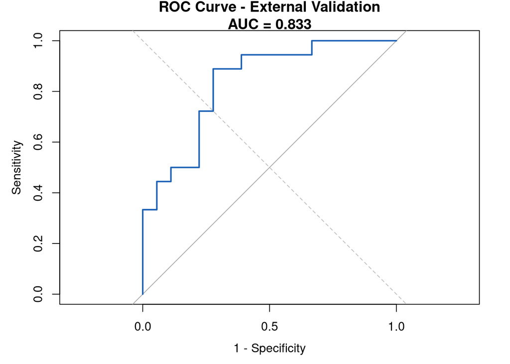

Overall, the combination of recursive feature elimination and PLS-DA resulted in a reduced metabolite set that maintained classification performance on independent data. The evaluation metrics and uncertainty estimates suggest that the final model provides a reasonable balance between dimensionality reduction and predictive performance in this dataset.

[figure not shown]